# Our Swiss Roll Era

# Regression on a Swiss Roll

An ’00s thing

[interactive chart not shown]

## Can you color the test data using linear regression?

$$\underset{\textcolor{lightgray}{\text{color}}}{W_i} = f(X_i, Y_i, Z_i)$$

### Training data

[interactive chart not shown]

### Test data

[interactive chart not shown]

## You can if you unroll it first

$$W_i = f(U_i,V_i) + \epsilon_i$$

### Training Data

[figure not shown]

### Test Data

[figure not shown]

## And you can unroll it well enough

### Training Data

[figure not shown]

### Test Data

[figure not shown]

I’ve unrolled it using Isomap Tenenbaum (1997). See Figure 1.

## This is a fancy version of PCA

- A Sheet
- A Swiss Roll
- Cigarette Consumption 1986-1989

[interactive chart not shown]

[figure not shown]

[interactive chart not shown]

[figure not shown]

[interactive chart not shown]

[figure not shown]

## Where’s all this 20 years later?

[figure not shown]

- Maybe the thing that’s cool about it was what killed it.
  - With the Swiss Roll, you can see if working.
  - With the Cigarette consumption data, you can see it *not working*.
- That’s if you’re looking for a rolled-up two-dimensional sheet.
  - If you’re looking for a ‘higher-dimensional sheet’, you can’t visualize what’s going on.
  - But perhaps what’s going on is something good.
- After the excitement died down, we started seeing that proven for methods like this.
  - One such method is linear regression after Kernel PCA.
  - KPCA is a simplified version of the ISOMap Unrolling technique I showed you.

## Optimality Results

- What was proven a form of *semi-agnostic optimality*
- *Agnostic* in the sense that we’re not assuming the thing that motivated the method.
  - We’re not assuming there’s a sheet or a swiss roll hidden in the data.
- *Semi-agnostic* because we are assuming something.
  - We’re assuming the function we’re estimating has some unknown degree of smoothness.
  - In particular, the existence of some number $p$ of bounded derivatives.

  $$W_i = f(X_i) + \epsilon_i \qfor \mathcal{F}_p = \{ f : \lVert f^{(p)} \rVert_{L_2} < \infty \}.$$
- *Optimality* means that, no matter what $p$ is, the method is about as good as any other.
  - No method, even ones that ‘know $p$’, can do better for all functions in $\mathcal{F}_p$.
  - See e.g. Dicker, Foster, and Hsu (2017).

## Lessons

[interactive chart not shown]

[figure not shown]

- Be careful about selling a method based on a quirky example or two.
- Be careful about writing off a method because its motivating story is quirky.
  - When you don’t believe the motivating story, that doesn’t mean you need a new method.
  - It means you need an understanding of the method that doesn’t assume the story is true.

# Panels and Swiss Rolls

## Modeling Panel Data

$$Y_{it} = f(u_i, t) \textcolor{lightgray}{+ \epsilon_{it}}$$

- 2FE
- Linear
- Roll
- Real

[figure not shown]

[interactive chart not shown]

[figure not shown]

[interactive chart not shown]

[figure not shown]

[interactive chart not shown]

[figure not shown]

[interactive chart not shown]

## Panel vs. Regression Analysis

### Regression

$$\begin{aligned}
W_i &= f(X_i, Y_i, Z_i) \textcolor{lightgray}{+ \epsilon_i} && \qqtext{ is what we want to estimate.} \\
&\approx \hat f(\hat U_i, \hat V_i) && \qqtext{ is an unrolling approach to estimating it. }
\end{aligned}$$

### Panel

$$\begin{aligned}
W_i &= f(U_i, V_i) \textcolor{lightgray}{+ \epsilon_i} && \qqtext{ is what we want to estimate} \\
&\approx \tilde f(X_i, Y_i, Z_i) && \qqtext{ is what we can do with the observed data. } \\\
&\approx \hat f(\hat U_i, \hat V_i) && \qqtext{ is an unrolling approach to estimating it. }
\end{aligned}$$

- The methods we use for these two tasks can be pretty similar.
- e.g. methods like Trajectory Balancing can be reinterpreted as a form of Regression after Kernel PCA Unrolling. (See Hirshberg, Maleki, and Zubizarreta 2019)
- That’s inevitable. Given the data we have, we’re trying to solve the same prediction problem.
- But the relationship between what we have and what we want to estimate is different.
- This means the way we understand the two tasks should be different.

## Understanding panel data analysis

[interactive chart not shown]

$$\begin{aligned}
W_i &= f(U_i, V_i) \textcolor{lightgray}{+ \epsilon_i} && \qqtext{ is what we want to estimate} \\
&\approx \tilde f(X_i, Y_i, Z_i) && \qqtext{ is what we can do with the observed data. } \\\
&\approx \hat f(\hat U_i, \hat V_i) && \qqtext{ is an unrolling approach to estimating it. }
\end{aligned}$$

- Approach 1
- Approach 2
- Approach 3
- Approach 4

Make assumptions about the latent structure of the data.

- e.g. 2-way fixed effects models, linear factor models.
- e.g. smooth nonlinear factor models, which can be approximated well by linear factor models (Udell and Townsend 2019)
  - This why we might expect semi-agnostic optimality from linear factor approaches…
  - … in a sense like what Dicker, Foster, and Hsu (2017) showed for KPCA Regression.
  - But do we buy smooth nonlinear factor models as much as we buy smooth regression models?

$$\underset{\textcolor{lightgray}{\text{panel version}}}{\mathcal{F}_p = \{ f(u,t) : \lVert f^{(p)} \rVert_{L_2} < \infty \}} \qqtext{ vs. } \underset{\textcolor{lightgray}{\text{regression version}}}{\mathcal{F}_p = \{ f(x) : \lVert f^{(p)} \rVert_{L_2} < \infty \}}$$

Do semi-agnostic analysis based on more abstract models of the data.

- e.g. can we come up with a simple large-sample approximation to the synthetic control estimator without strong assumptions about latent structure?
- This is something I’ve been working on. (Arkhangelsky and Hirshberg 2023) is a start.
- A motivating question.
  - Statistical analysis requires that *something* be random—usually random sampling from a population or randomization of treatment.
  - It’s not clear what, if anything, is actually random in panel data. But often, we can at least imagine that units select treatment with some (unknown) probability.
  - Can we do statistical inference assuming that imagined randomization and little else?

Look at how it behaves with semi-synthetic data, e.g. placebo tests.

- Checking that, when we estimate the effect of a treatment that hasn’t actually happened, we estimate (almost) zero.
- Comparing our actual effect to these placebo estimates to get a sense of how real it is.

Look at what the estimator is actually doing and see if it makes sense.

- To understand the usual version of ‘diff in diff’ with staggered treatment adoption, Goodman-Bacon (2021) decomposed a common 2FE-based estimator into a linear combination of simple 2x2 difference-in-differences. Sometimes the weights were negative. Not good.
- To understand a placebo test for a new-and-improved staggered-adoption diff-in-diff, Li and Strezhnev (2025) decomposed placebo estimate it uses. A number of terms in the analogous decomposition of the real estimator are replaced with zeros in the placebo estimator. Not good.

## Approach 4 in (Asher, Hazlett, and Xu 2025)?

[figure not shown]

## References

Arkhangelsky, Dmitry, and David Hirshberg. 2023. “Large-Sample Properties of the Synthetic Control Method Under Selection on Unobservables.” *arXiv Preprint arXiv:2311.13575*.

Asher, Samuel G. Z, Chad Hazlett, and Yiqing Xu. 2025. “Trajectory Balancing: A General Weighting Approach to Causal Inference with Panel Data.”

Dicker, Lee H, Dean P Foster, and Daniel Hsu. 2017. “Kernel Ridge Vs. Principal Component Regression: Minimax Bounds and the Qualification of Regularization Operators.”

Goodman-Bacon, Andrew. 2021. “Difference-in-Differences with Variation in Treatment Timing.” *Journal of Econometrics* 225 (2): 254–77.

Hirshberg, David A, Arian Maleki, and Jose R Zubizarreta. 2019. “Minimax Linear Estimation of the Retargeted Mean.” *arXiv Preprint arXiv:1901.10296*.

Li, Zikai, and Anton Strezhnev. 2025. “Benchmarking Parallel Trends Violations in Regression Imputation Difference-in-Differences.”

Tenenbaum, Joshua. 1997. “Mapping a Manifold of Perceptual Observations.” *Advances in Neural Information Processing Systems* 10.

Udell, Madeleine, and Alex Townsend. 2019. “Why Are Big Data Matrices Approximately Low Rank?” *SIAM Journal on Mathematics of Data Science* 1 (1): 144–60.

# Appendix

## About Isomap

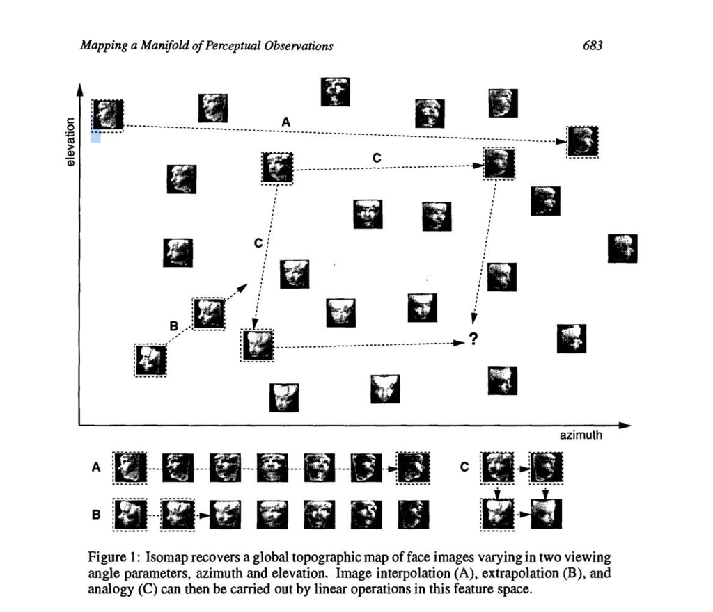

Figure 1